# MIX:多通道信息交叉用于文本匹配

# 摘要

短文本匹配在信息检索、问答、对话系统等自然语言处理任务中发挥着重要作用。传统的文本匹配方法依赖于预定义的模板和规则。然而，对于字数有限的一小段文本，这些规则不能很好地推广到未观察到的数据。随着深度学习在计算机视觉、语音识别和推荐系统等领域的成功，近年来人们致力于将深度神经网络模型应用到自然语言处理任务中，以降低人工特征工程的成本。本文提出了一种用于工业环境中文本匹配的多通道卷积神经网络(CNN)模型——多通道信息交叉(MIX)的设计，并对句子和语义特征进行了额外的注意力机制。MIX将不同粒度的文本片段进行比较，形成一系列多通道相似矩阵，然后与另一组精心设计的注意矩阵交叉，将丰富的句子结构暴露给深度神经网络。我们在腾讯的Venus分布式计算平台上实现了MIX并进行了部署。由于精心设计的多通道信息交叉，评估结果表明，MIX在英语WikiQA数据集上的归一化折现累积增益(NDCG@3)至少比许多最先进的深度神经网络模型高出11.1%。此外，我们还在腾讯QQ浏览器的搜索服务上对真实用户进行了在线A/B测试。结果表明，MIX提高了返回结果的点击量5.7%，这是由于查询文档匹配的准确性提高了，这表明MIX在实际生产环境中的性能优越。

CCS的概念：

信息系统- >信息检索;学习等级;问题回答;•计算方法- >神经网络;

关键词：

文本匹配，特别检索，问题回答，卷积神经网络，注意机制。

# 1介绍

在信息检索、问答和对话系统等许多自然语言处理任务中，短文本匹配起着至关重要的作用。早期的文本匹配方法包括检索知识库自动回答问题，以及基于单词匹配和特征交叉的自组织检索。然而，这些方法都依赖于手动定义的模板和规则，这限制了良好调优模型的可泛化性及其针对不同任务需求的可移植性。近年来，深度神经网络模型的发展为提高自然语言处理性能带来了新的机遇。通过减轻人工特征工程的需要，深度网络模型可以更好地推广到各种任务。近年来，针对基于卷积神经网络和递归神经网络的短文本匹配，提出了许多深度网络结构。

在这篇文章中,我们实现了一个现实最近的大范围的深度学习文本匹配技术,指出,尽管各自的新奇事物深层网络模型,仍然存在显著的空间性能改进这些方法付诸实践时,特别是当深模型结合的分析语言结构和语义特征。特别地，我们提出了多通道信息交叉(MIX)的设计，这是一种用于文本匹配的多通道卷积神经网络(CNN)模型，在腾讯的生产环境中取得了优异的性能。

MIX是一种新型的多粒度CNNs融合技术，具有精心设计的注意机制。MIX背后的一般思想可以概括为:首先,MIX表示文本片段，其特征提取于与词汇、短语、语法和语义、词汇频率和权重甚至语法信息相关的多个粒度，我们从实验中观察到，这是充分实现深度模型潜力的必要实践。将多层特征的文本匹配结合起来，可以最大限度地提高深层体系结构表达各层局部依赖关系的能力，并最大限度地减少卷积过程中的信息损失。其次，MIX还提出了一种新的融合技术，将多个通道的匹配结果进行融合。MIX有两种类型的通道，通过这两种通道，两个文本片段的特性可以相互作用。第一个类是一个语义信息通道，它表示文本的意义，如一元图、二元图和三元图。第二种类型的通道包含结构信息，如术语权重、词性和命名实体以及交互的空间相关性。其中，语义信息通道起着相似匹配的作用，结构信息通道起着注意力机制的作用。此外，MIX使用3D卷积内核处理这些堆叠的层，从多个通道提取抽象特征，并通过多层感知器组合输出。通道组合机制允许MIX轻松地将新通道合并到其学习框架中，从而使MIX能够适用于广泛的任务。

我们在腾讯的Venus分布式处理平台上实现并部署了MIX。我们基于多个数据集，通过在线A/B测试对中国移动浏览器市场份额最大的腾讯QQ移动浏览器流量进行MIX评估。在线下评测部分，我们使用英文问答数据集WikiQA和中文搜索结果数据集QQ手机浏览器进行MIX测试。WikiQA是一个可公开访问的数据集，包含由Microsoft提供的开放域问答对。在WikiQA数据集上，MIX在NDCG@3上的性能至少比许多最先进的方法高出11.1%，NDCG@3是衡量排名质量的流行指标，在搜索引擎评估中被广泛采用。另一个中文搜索结果数据集是在用户同意的情况下从腾讯QQ浏览器中收集的，并从每天1000万活跃用户的在线搜索流量中采样。数据集包括120,000个查询文档条目和审阅器生成的标签，这些标签表示数据集中每个查询文档对的匹配程度。在这个数据集中，MIX在NDCG@3方面的性能至少比其他所有最先进的方法高出8.2%。

此外，在腾讯QQ手机浏览器的在线A/B测试中，MIX比没有MIX的流量增加了5.7%的点击率(CTR)。评估结果显示了MIX在工业环境中提高文本匹配精度方面的优越能力，以及它在不同语言的数据集之间进行泛化的能力。

# 2初期和背景

根据转换和匹配的顺序,文本匹配模型可以分为两类:基于表示和基于交互。前者首先将文本的每一段都转换成一个带有深度神经网络的张量表示，如深度语义相似模型(DSSM)、卷积深度语义相似模型(CDSSM)、多粒度CNN(Multigranccn)、卷积神经张量网络(CNTN)等。然后在两个文本实例的向量表示上执行它们之间的匹配。反之，后一种方法首先为每一对文本生成一个交互矩阵，然后利用神经网络提取有用的特征，从交互矩阵中学习有意义的匹配模式，如Arc-I、MatchPyramid和DRMM。

## 基于2.1表示方法

基于表示的方法通过深度神经网络从文本输入生成分布式表示。使用该方法的工作很多，包括基于CNN、基于RNN和基于树的RNN方法。它们受到孪生网络结构的启发，首先生成文本输入的向量表示，然后计算匹配度为两个向量之间的欧氏距离。它们的主要区别在于构造表示的过程和计算匹配度的方法。

Huang等人提出了DSSM。DSSM是将深度神经网络模型应用于文本匹配的最早研究成果。在DSSM中，每段文本都通过一个5层神经网络进行矢量化，然后将文本对的匹配分数计算为它们表示形式之间的余弦相似度。该模型首先将句子分割成一个由三个字母组成的列表，然后将这个由三个字母组成的包散列成一个向量。将三字母层输入到一个三层MLP中，生成整个句子的语义向量。与传统的文本匹配模型相比，DSSM在NDCG度量上有明显的改进。

在DSSM之后，Shen等人认为，DSSM中的MLP包含了太多的参数，这增加了模型的整体复杂性，并且存在较大的过拟合风险。三字母袋模型也忽略了词的位置，这是文本匹配的重要特征。因此，Shen等人提出了卷积DSSM，它将单词序列作为输入。与DSSM相比，CDSSM在生成文本表示时用CNN替换MLP。在CDSSM中，匹配精度进一步提高。

邱等人提出了CNTN，它也利用CNN来表示文本输入的语义。然而CNTN并没有采用欧氏距离或MLP相互作用，而是用张量来匹配文本表示，从而更好地描述了两种表示之间的复杂关系。张量神经网络是由Socher等人提出的。CNTN在社区问答任务中表现出色。

## 2.2基于交互方法

与表示方法相比,基于交互方法的目标是捕捉直接匹配的特点:匹配的程度和结构。这种方法更加直观，符合语言匹配问题的本质。给定两篇文本，首先考虑关键词的匹配，然后考虑它们的相对位置。最后将两种特征结合起来计算最终匹配度。最近的研究表明，这种方法在多个文本匹配任务中表现得更好。

Hu等人提出了ARC-II，它首先将一个句子表示为一个单词向量序列，然后调整第一个卷积层的滑动窗口，将重点放在相邻的单词向量上。第一个卷积层输出一个三维张量，表示两句话之间的关系。然后，在三维张量上进行多重反卷积池运算。最后，给出了一个描述两句话之间关联的高级抽象表示。使用MLP将该抽象转换为单个匹配度。与DSSM相比，ARC-II考虑了句子中单词的顺序，因此能够更好地描述一般匹配与元素明智匹配之间的关联。从评价结果来看，ARC-II的性能也优于DSSM和CDSSM。

MatchPyramid是庞等人提出的。本文将两篇文本之间的相互作用形式化为一个匹配矩阵。在二维矩阵上进行卷积，提取相互作用的模式。匹配分数由一个完全连接的网络计算。MatchPyramid将匹配矩阵定义为两个句子单词之间的匹配度矩阵。该模型利用余弦相似度计算每对匹配度。本质上，匹配矩阵可以看作是灰度图像。类似于图像分类任务，然后在这个“图像”上执行多层卷积和池。

DRMM是由Guo等人提出的。当大部分的NLP任务都集中在语义匹配上时，Ad-hoc检索任务主要是相关匹配，即关联匹配。确定文档是否与给定查询相关。DRMM是一个以交互为中心的模型，它在查询术语与文档术语级别上使用了联合的深层体系结构。具体来说，DRMM首先基于术语嵌入在查询和文档中的每对术语之间构建本地交互。对于每个查询项，模型将可变长度的本地交互映射为固定长度的匹配直方图。在此基础上，利用前馈匹配网络学习层次匹配模式，生成匹配分数。最后，将每个查询项的得分与计算聚合权重的术语门控网络进行聚合，生成总体匹配得分。

最近的KNRM和卷积-KNRM直接从两段文本中进行ngram嵌入之间的交互，并使用内核池层组合交叉匹配层来生成匹配分数。

基于交互的方法在考虑匹配度和匹配结构的同时，在多个文本匹配任务中取得了显著的改进。然而这些方法经常遭受以下缺点:

(1)单词或n-gram被认为是基本的语义单位，忽略了自然语言的许多其他有用的方面，如句法信息或句子之间的交叉引用。

(2)很难很好地描述全局匹配和局部匹配之间的关系。实际上，文本对中关键部分或特定模式的匹配通常比全局结构的匹配更重要。

(3)缺乏统一的多方面匹配集成机制。仅通过只添加新的匹配特性，模型很难扩展到新的任务。

总的来说，上述许多模型过于依赖神经网络的泛化能力以及训练数据的质量。

# 3MIX模型

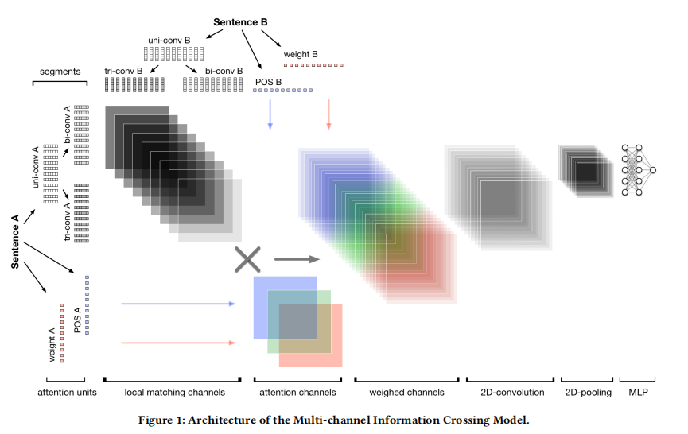

在本节中，我们描述了在多通道信息交叉(MIX)中为提高文本匹配性能而采用的详细模型。我们将全局匹配定义为两个句子之间的匹配，局部匹配定义为句子内文本元素之间的匹配。受基于交互的模型的启发，通过结合使用全局匹配和局部匹配技术，MIX模型两段文本之间的相关性。MIX凭借深度神经网络强大的表征性学习能力，能够分层次、多维度地描述文本匹配问题的本质。如图1所示,有效地将文本匹配问题划分为子问题如下:

首先，正如我们在图1的左上方所看到的，句子被解析成不同粒度的文本片段，例如unigram、bigram和trigram。这样，MIX通过为文本(可以是单词、术语或短语)找到最合适的语义表示，从而提高了局部匹配的准确性。这里的目标是在不同层次的交互中捕获最多的信息。

其次，如图1中注意单元部分所示，提取相对权重、词性标记等语法信息，设计注意通道中的注意矩阵，封装丰富的结构模式。利用这种方法，我们首先研究了全局匹配和局部匹配之间的关系。然后，我们论证了我们的注意机制是如何在局部匹配的基础上构建全局匹配，从而提高整体匹配质量的。

第三，如图1中的加权信道和二维卷积部分所示，我们将局部匹配的信道和注意信道交叉，提取出重要的特征组合进行局部匹配。我们将在下面的小节中详细描述MIX的机制。

## 3.1局部匹配

在许多相关的工作中，文本匹配是通过匹配不同层次的词嵌入向量来实现的。然而，将单词嵌入向量作为语义表示的唯一形式，会导致信息丢失，破坏高层次匹配的直觉。

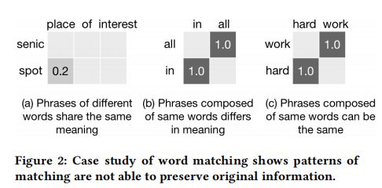

如图2所示，基于嵌入向量的局部匹配有两个局限性。一方面，在图2(a)中，短语senic spot和短语place of interest在语义上是相似的。然而，它们的词嵌入向量之间的相似性较低，这对整体匹配结果产生了不利的影响。另一方面，词组all in和词组in all由完全相同的一组单词组成。但是，它们的含义完全不同，如图2(b)所示。由于这些输入表示的弱点，即使是像深度神经网络这样的强学习者也很难提取出准确的匹配模式。再考虑图2(c)所示的另一个例子，hard work和work hard的匹配矩阵与all in和in all的矩阵具有完全相同的模式。然而，前两个词的意思非常相似，而后两个词的意思完全不同。本案例研究表明，单纯基于嵌入向量的文本匹配在很大程度上是无效的。换句话说，仅从一个角度进行文本匹配不能产生令人满意的结果。

为了改进这种单视角匹配，我们建议首先将一段文本分割成多重字符序列。

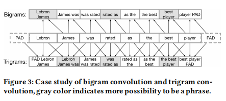

我们从文本中选择一个单词作为核心单词。然后，我们使用一个固定长度的窗口来组合它周围的单词。在英语中，一个最小的语义单元通常包含1到3个单词，因此我们使用大小为1到3的卷积窗口来表示短语的整体含义。对于text1和text2，我们分别应用m和n大小的卷积窗，其中m属于{1,2,3}，n属于{1,2,3}。如图3所示，我们以2-gram卷积和3-gram卷积为例，将卷积形式化为式(1)。在训练阶段，匹配现有英语短语的N-gram具有更高的权重。

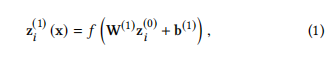

其中zi(0)(x)表示位置i嵌入层的unigram嵌入;zi(1)(x)给出位置i的卷积结果;W(0)为卷积核函数的参数集，f(•)为激活函数Relu, zi0为位置i处卷积的嵌入层段

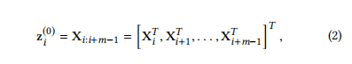

其中m为滑动窗口的大小，该滑动窗口将过滤大小的单词的向量从句子输入X串联起来。

在训练阶段的开始，很难在每个卷积滤波器中选择一个合适的窗口大小，因此我们保留了所有可能的滤波器大小对之间的相互作用。我们希望在接下来的训练阶段能够在不同的渠道中学习合适的权重。

为了方便起见，我们将text1的m-gram序列与text2的n-gram序列之间的交互通道命名为Layer m,n。

## 3.2局部匹配和全局匹配

在文本匹配的设想下，全局匹配很大程度上依赖于局部匹配的组合。然而，在现实中局部匹配的结果并不会对全局匹配的结果产生同等的影响。为了捕捉权重上的这种差异，我们将注意力机制引入全局匹配过程。我们初始化注意力矩阵具有以下特点:

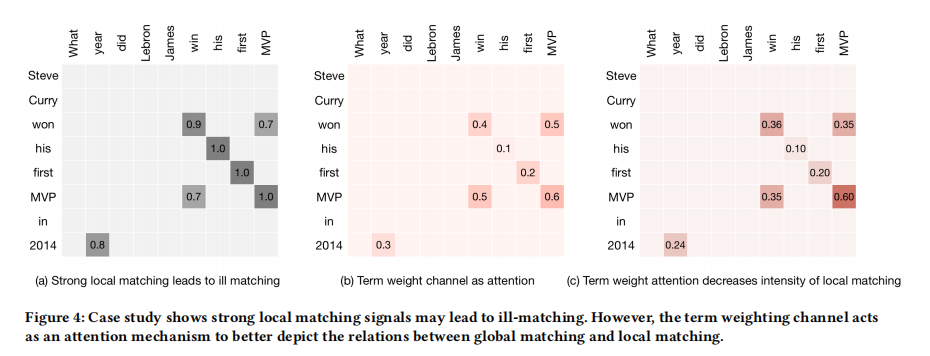

首先，交互矩阵中不同项的权重应该反映出每个匹配信号的重要性。换句话说，在考虑两个句子时，两个关键短语的匹配比两个琐碎短语的匹配更有意义。以图4中的问答题为例。在图4(a)中，回答史蒂夫·库里在2014年赢得他的第一个MVP看起来和问勒布朗·詹姆斯是哪一年赢得他的第一个MVP非常相似。它们在多个单词中完全匹配。从基于嵌入的匹配角度来看，这是一个很好的匹配，但在现实中并不正确。可以看出，不准确是由于缺少关键词权重造成的。这对句子在win，his，first，MVP等方面匹配得很好，但是勒布朗·詹姆斯并没有考虑到重要话题的不匹配。

我们设计了一个element-wise(元素-明智)的注意层来衡量每个交互的重要性。如图4(b)所示，注意层工作像在原始匹配矩阵之上加上一个mask，和在交互过程中初始化为术语逆文档频率(IDF)的乘积。诸如his-his, first-first, year-2014等琐碎术语交互的权重明显小于其他术语。将注意层叠加在原始匹配层上，进行点积运算，得到如图4(c)所示的加权匹配矩阵，有效降低了琐碎交互的强度。

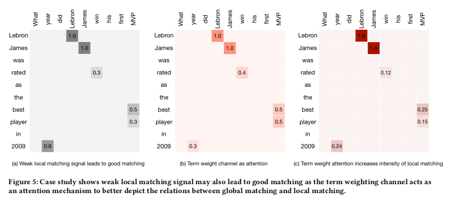

相反,如图5所示,当回答詹姆斯被评为最好的球员在2009年，匹配与问哪一年詹姆斯赢得他的第一个MVP,尽管当地匹配信号并不激烈,关键词匹配的勒布朗·詹姆斯对匹配的结果。从图5(c)可以看出，应用图5(b)所示的注意机制后，关键短语的局部匹配得到了很大的增强，从而提高了匹配精度。最后，注意力层的权重也是可以训练的。

其次，词性(词性)特征也是衡量术语交互重要性的好方法。例如，两个命名实体(比如两个人名)之间的匹配总是比普通名词和形容词之间的匹配更重要。理想情况下，在训练数据丰富、模型通用性强的情况下，该特征可以在训练过程中自动学习。然而，在实际应用中，我们通常只有有限的训练数据，这些数据可能会也可能不会捕捉到POS特性的强大影响。因此，引入一些与有用的POS匹配相关的先验知识是非常必要的。

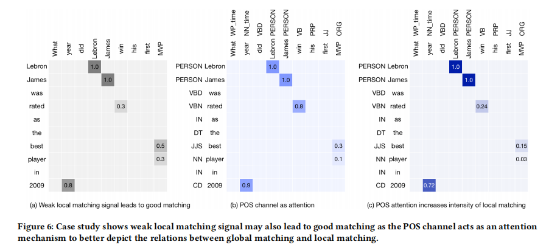

如图6所示，基于图6(a)的原始匹配结果，我们从两段文本中提取POS标签，并用图6(b)中的POS标签交互初始化这个注意层。如我们所见,以下交互POS标签显示更高的重要性:两个人名之间的互动标签,两个动词(VB)之间的相互作用,以及相互作用在代词关于时间(WP_time)和基数(CD)。将post标签注意通道应用于图6(a)后，图6(c)强调关键的局部匹配信号。

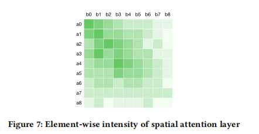

第三，单词在句子中的位置也会影响局部匹配和全局匹配之间的关系。对于某些任务，存在空间重要性的模式。以问答(QA)任务为例，问答的开始部分通常比正文的其余部分更重要。如图7所示，经过空间注意层的训练后，该图表明交互的重要性确实与空间信息不同。结合空间权重可以更好地捕捉全局匹配和局部匹配之间的关系。

为了方便起见，我们将基于词汇权重的注意层命名为Att(tw)，基于词性特征的注意层命名为Att(pos)，基于词性位置的注意层命名为Att(spatial)。此外，我们将带有注意层Att(ch)的局部匹配信道层的权值表示为层数Layer m,n * Att(ch)。

我们创建了注意层和局部匹配层的排列。如图1所示,我们构建3•M•N层的形式:Att(ch) * Layer m,n，ch属于(tw、pos、spatial),m属于{1,…,M}， n属于{1,…,N}。通过从多个角度提取信息，构建注意层，有效地建立了全局匹配与局部匹配的关系模型。在本文中，我们提出了一种结合多通道文本交互而不丧失通用性的模式。

## 3.3的组合匹配

在3.1中，我们构造了多个局部匹配层。在3.2中，我们着重从三个角度运用注意层来匹配关键信息。然而，加权局部匹配的组合尚未得到很好的建模。为了解决这个问题,我们讨论这个过程在两个方面:第一,不同层的结合。正如前面提到的,每一层都可能是这些类型之一:Att(ch)•Layer(m,n), ch属于(tw、pos、spatial),m 属于{1,…,M}, n属于{1,…,N}}。此外，层内的局部匹配信息的组合。

虽然一开始看起来不太可能，但这两种组合都可以通过卷积有效地建模。因为我们这里的目标是将所有有用的信息合并到一个最终的输出矩阵中，所以我们需要一种方法，可以迭代地发现一个或几个关键的交互，并集中于潜在的大型交互矩阵中的一个或几个关键交互，甚至是来自多个层的一组矩阵。由于卷积的滑动窗口机制，卷积是这种操作的理想选择。我们公式化inter层和intra层组合程序:

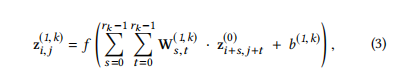

其中zi,j(l,k)给出特征图的输出;W(l,k)是从核1到核k的卷积核函数的参数;f(•)为激活函数Relu。zi+s,j+t(0)表示位置i,j,s,t处卷积的输入层块沿两轴偏移量。

除了滑动窗口机制,卷积有益也有两个属性:位置不变性和组合性。因为空间注意层已经封装了所有有用的位置信息，所以这个阶段额外的位置依赖只会给匹配结果添加更多的噪声。因此，聚合方法只需要提取有意义的局部匹配信号，而不需要考虑它们的位置，卷积可以方便地实现这一目标。它的第二个特性，合成性，与语言的本质是一致的。在英语中，最基本的组成部分是字母。通过把不同的字母组合在一起，我们有不同的单词表达不同的意思。通过进一步组合不同的单词，我们得到短语和句子，这可以包含更复杂的想法。卷积以类似的方式工作，将小的局部特征块合并到更高层次的表示中。CNN从局部匹配信号中提取特征，一直提取到全局匹配结果，这是很直观的。

在此基础上，我们得到了一个统一的端到端结构来建模多通道匹配信息，并提出了一种将通道与抽象的高层文本匹配特征相结合的方法。

# 4性能评估

•深层语义相似模型(DSSM); •卷积深层语义相似性模型(CDSSM); •卷积神经网络结构I (ARC-I); •卷积神经网络架构II (ARC-II); •MatchPyramid (MP); •深度关联匹配模型(DRMM); •2x2通道的多通道信息交叉(MIX-4channel)。如第3.1节所述，我们计算了两个句子在局部匹配阶段的一元卷积结果与二元卷积结果之间的笛卡尔积。 •3x3通道多通道信息交叉(MIX-9channel)。如第3.1节所述，我们在局部匹配阶段计算两句话的一元卷积结果、二元卷积结果和三元卷积结果之间的笛卡尔积。 •具有空间注意的多通道信息交叉(MIX-spatial)。基于MIX-99channel，如第3.2节所述，我们将局部匹配矩阵与空间注意层进行加权。 •多通道信息交叉与POS关注(MIX-POS)。基于混合空间，如第3.2节所述，我们增加了局部匹配矩阵与POS注意层的权重。具体来说，我们进行了名称实体重新编码(NER)，以进一步丰富POS信息。POS和NER标记是使用自然语言工具包(NLTK)提取的。 •多通道信息交叉，关注项权重(MIX-weight)。基于MIX-POS，如第3.2节所述，我们增加了局部匹配的权值矩阵与项权注意层的权值。虽然这一层是可训练的，但我们仍然使用两个术语的逆文档频率(IDF)之间的标准化乘积初始化它。

NDCG@p是引入的一种流行的排名质量度量方法。它也被广泛应用于搜索引擎性能评估。NDCG@p的思想是估计给定特定查询的第一个p搜索结果中相关信息的数量。如果高度相关的文档稍后出现在搜索结果中，它还会给最终得分增加一个惩罚。NDCG@p得分总是在0到1之间，值越高表示性能越好。在这项工作中，我们报告了NDCG@3和NDCG@5的评分。

MAP是信息检索(IR)任务的另一个常见度量。它建立在平均精度(AP)度量的基础上，其中AP度量特定查询的相关文档与所有检索到的文档的比例。现在假设我们有Q个查询，MAP分数就是它们的AP分数的平均值，也就是0到1之间。直观地说，MAP得分越高表示性能越好。

# 5结束语

在本文中，我们提出了一种新的多通道信息交叉(MIX)技术，它是一种新的CNNs融合技术，可以在真实的生产环境中提高文本匹配质量。MIX结合了多通道文本特性，并在关键特性交互上添加了三个注意层，以产生更精确的匹配结果。我们在腾讯的Venus计算平台上实现了MIX，并进行了各种实际的优化。基于公开的维基百科数据集和另一个从腾讯QQ移动浏览器的真实搜索日志中收集的数据集进行的离线评估显示，MIX的性能远远超过许多最先进的方法。在接下来的21小时内对真实用户进行的在线A/B分割测试中，MIX比传统的文本匹配算法提高了5.7%的点击率(CTR)。